# IFN701: Zillow’s Home Value Prediction (Zestimate) — Round 1 Logerror Prediction

# 2.1.1 Predict month data based on previous one month data

# Prepare the different sizes of training data and testing data

```r
mergeid16B <- replace(mergeid16B, is.na(mergeid16B), 0)
mergeid16BP <- select(mergeid16B, parcelid, logerror, transactiondate,month, bathroomcnt, bedroomcnt, calculatedfinishedsquarefeet, fips,latitude, longitude, lotsizesquarefeet, propertylandusetypeid, rawcensustractandblock, regionidcity, regionidzip, roomcnt, yearbuilt, assessmentyear, taxvaluedollarcnt, taxamount, censustractandblock)
jan16 <- subset(temp16df, month == "1")
feb16 <- subset(temp16df, month == "2")
mar16 <- subset(temp16df, month == "3")
apr16 <- subset(temp16df, month == "4")
may16 <- subset(temp16df, month == "5")
jun16 <- subset(temp16df, month == "6")
jul16 <- subset(temp16df, month == "7")
aug16 <- subset(temp16df, month == "8")
sep16 <- subset(temp16df, month == "9")
oct16 <- subset(mergeid16BP, month == "10")
nov16 <- subset(mergeid16BP, month=="11")
dec16 <- subset(mergeid16BP, month =="12")
```

Jan data predicts Feb data

```r
model16_jan = lm(logerror ~ bathroomcnt+bedroomcnt+calculatedfinishedsquarefeet+fips+latitude+ longitude+lotsizesquarefeet+propertylandusetypeid+rawcensustractandblock+regionidcity+regionidzip+roomcnt+yearbuilt+ taxvaluedollarcnt+taxamount+ censustractandblock, data = jan16)
pre16_feb <- data.frame(predict(model16_jan, feb16))
mse(pre16_feb,feb16$logerror)
```

```
## [1] 0.03943015
```

Feb data predicts Mar data

```r
model16_feb = lm(logerror ~ bathroomcnt+bedroomcnt+calculatedfinishedsquarefeet+fips+latitude+ longitude+lotsizesquarefeet+propertylandusetypeid+rawcensustractandblock+regionidcity+regionidzip+roomcnt+yearbuilt+ taxvaluedollarcnt+taxamount+ censustractandblock, data = feb16)
pre16_mar <- data.frame(predict(model16_feb, mar16))
mse(pre16_mar,mar16$logerror)
```

```
## [1] 0.02967089
```

Mar data predicts Apr data

```r
model16_mar = lm(logerror ~ bathroomcnt+bedroomcnt+calculatedfinishedsquarefeet+fips+latitude+ longitude+lotsizesquarefeet+propertylandusetypeid+rawcensustractandblock+regionidcity+regionidzip+roomcnt+yearbuilt+ taxvaluedollarcnt+taxamount+ censustractandblock, data = mar16)
pre16_apr <- data.frame(predict(model16_mar, apr16))
mse(pre16_apr,apr16$logerror)
```

```
## [1] 0.02761392
```

Apr data predicts May data

```r
model16_apr = lm(logerror ~ bathroomcnt+bedroomcnt+calculatedfinishedsquarefeet+fips+latitude+ longitude+lotsizesquarefeet+propertylandusetypeid+rawcensustractandblock+regionidcity+regionidzip+roomcnt+yearbuilt+ taxvaluedollarcnt+taxamount+ censustractandblock, data = apr16)
pre16_may <- data.frame(predict(model16_apr, may16))
mse(pre16_may,may16$logerror)
```

```
## [1] 0.02275491
```

May data predicts June data

```r
model16_may = lm(logerror ~ bathroomcnt+bedroomcnt+calculatedfinishedsquarefeet+fips+latitude+ longitude+lotsizesquarefeet+propertylandusetypeid+rawcensustractandblock+regionidcity+regionidzip+roomcnt+yearbuilt+ taxvaluedollarcnt+taxamount+ censustractandblock, data = may16)
pre16_jun <- data.frame(predict(model16_may, jun16))
mse(pre16_jun,jun16$logerror)
```

```
## [1] 0.02305983
```

June data predicts July data

```r
model16_jun = lm(logerror ~ bathroomcnt+bedroomcnt+calculatedfinishedsquarefeet+fips+latitude+ longitude+lotsizesquarefeet+propertylandusetypeid+rawcensustractandblock+regionidcity+regionidzip+roomcnt+yearbuilt+ taxvaluedollarcnt+taxamount+ censustractandblock, data = jun16)
pre16_jul <- data.frame(predict(model16_jun, jul16))
mse(pre16_jul,jul16$logerror)
```

```
## [1] 0.02296013
```

July data predicts Aug data

```r
model16_jul = lm(logerror ~ bathroomcnt+bedroomcnt+calculatedfinishedsquarefeet+fips+latitude+ longitude+lotsizesquarefeet+propertylandusetypeid+rawcensustractandblock+regionidcity+regionidzip+roomcnt+yearbuilt+ taxvaluedollarcnt+taxamount+ censustractandblock, data = jul16)
pre16_aug <- data.frame(predict(model16_jul, aug16))
mse(pre16_aug,aug16$logerror)
```

```
## [1] 0.02606143
```

Aug data predicts Sep data

```r
model16_aug = lm(logerror ~ bathroomcnt+bedroomcnt+calculatedfinishedsquarefeet+fips+latitude+ longitude+lotsizesquarefeet+propertylandusetypeid+rawcensustractandblock+regionidcity+regionidzip+roomcnt+yearbuilt+ taxvaluedollarcnt+taxamount+ censustractandblock, data = aug16)
pre16_sep <- data.frame(predict(model16_aug, sep16))
mse(pre16_sep,sep16$logerror)
```

```
## [1] 0.02271136
```

Sep data predicts Oct data

```r
model16_sep = lm(logerror ~ bathroomcnt+bedroomcnt+calculatedfinishedsquarefeet+fips+latitude+ longitude+lotsizesquarefeet+propertylandusetypeid+rawcensustractandblock+regionidcity+regionidzip+roomcnt+yearbuilt+ taxvaluedollarcnt+taxamount+ censustractandblock, data = sep16)
pre16_oct <- data.frame(predict(model16_sep, oct16))
mse(pre16_oct,oct16$logerror)
```

```
## [1] 0.01816775
```

Oct data predicts Nov data

```r
model16_oct = lm(logerror ~ bathroomcnt+bedroomcnt+calculatedfinishedsquarefeet+fips+latitude+ longitude+lotsizesquarefeet+propertylandusetypeid+rawcensustractandblock+regionidcity+regionidzip+roomcnt+yearbuilt+ taxvaluedollarcnt+taxamount+ censustractandblock, data = oct16)
pre16_nov <- data.frame(predict(model16_oct, nov16))
mse(pre16_nov,nov16$logerror)
```

```
## [1] 0.01945185
```

Nov data predicts Dec data

```r
model16_nov = lm(logerror ~ bathroomcnt+bedroomcnt+calculatedfinishedsquarefeet+fips+latitude+ longitude+lotsizesquarefeet+propertylandusetypeid+rawcensustractandblock+regionidcity+regionidzip+roomcnt+yearbuilt+ taxvaluedollarcnt+taxamount+ censustractandblock, data = nov16)
pre16_dec <- data.frame(predict(model16_nov, dec16))
mse(pre16_dec,dec16$logerror)
```

```
## [1] 0.04558319
```

# 2.1.2 Predict month data based on previous three month data

# Prepare the different sizes of training data and testing data

```r
jfm16 <- rbind(jan16,feb16,mar16)
fma16 <- rbind(feb16,mar16,apr16)
mam16 <- rbind(mar16,apr16,may16)
amj16 <- rbind(apr16,may16,jun16)
mjj16 <- rbind(may16,jun16,jul16)
jja16 <- rbind(jun16,jul16,aug16)
jas16 <- rbind(jul16,aug16,sep16)
aso16 <- rbind(aug16,sep16,oct16)
son16 <- rbind(sep16,oct16,nov16)
```

Jan+Feb+Mar data predicts Apr data

```r
model16_jfm = lm(logerror ~ bathroomcnt+bedroomcnt+calculatedfinishedsquarefeet+fips+latitude+ longitude+lotsizesquarefeet+propertylandusetypeid+rawcensustractandblock+regionidcity+regionidzip+roomcnt+yearbuilt+ taxvaluedollarcnt+taxamount+ censustractandblock, data = jfm16)
pre16_apr2 <- data.frame(predict(model16_jfm, apr16))
mse(pre16_apr2,apr16$logerror)
```

```
## [1] 0.02763571
```

Feb+Mar+Apr data predicts May data

```r
model16_fma = lm(logerror ~ bathroomcnt+bedroomcnt+calculatedfinishedsquarefeet+fips+latitude+ longitude+lotsizesquarefeet+propertylandusetypeid+rawcensustractandblock+regionidcity+regionidzip+roomcnt+yearbuilt+ taxvaluedollarcnt+taxamount+ censustractandblock, data = fma16)
pre16_may2 <- data.frame(predict(model16_fma, may16))
mse(pre16_may2,may16$logerror)
```

```
## [1] 0.02266364
```

Mar+Apr+May data predicts June data

```r
model16_mam = lm(logerror ~ bathroomcnt+bedroomcnt+calculatedfinishedsquarefeet+fips+latitude+ longitude+lotsizesquarefeet+propertylandusetypeid+rawcensustractandblock+regionidcity+regionidzip+roomcnt+yearbuilt+ taxvaluedollarcnt+taxamount+ censustractandblock, data = mam16)
pre16_jun2 <- data.frame(predict(model16_mam, jun16))
mse(pre16_jun2,jun16$logerror)
```

```
## [1] 0.02296181
```

Apr+May+June data predicts July data

```r
model16_amj = lm(logerror ~ bathroomcnt+bedroomcnt+calculatedfinishedsquarefeet+fips+latitude+ longitude+lotsizesquarefeet+propertylandusetypeid+rawcensustractandblock+regionidcity+regionidzip+roomcnt+yearbuilt+ taxvaluedollarcnt+taxamount+ censustractandblock, data = amj16)
pre16_jul2 <- data.frame(predict(model16_amj, jul16))
mse(pre16_jul2,jul16$logerror)
```

```
## [1] 0.02295128
```

May+June+July data predicts Aug data

```r
model16_mjj = lm(logerror ~ bathroomcnt+bedroomcnt+calculatedfinishedsquarefeet+fips+latitude+ longitude+lotsizesquarefeet+propertylandusetypeid+rawcensustractandblock+regionidcity+regionidzip+roomcnt+yearbuilt+ taxvaluedollarcnt+taxamount+ censustractandblock, data = mjj16)
pre16_aug2 <- data.frame(predict(model16_mjj, aug16))
mse(pre16_aug2,aug16$logerror)
```

```
## [1] 0.02595377
```

June+July+Aug data predicts Sep data

```r
model16_jja = lm(logerror ~ bathroomcnt+bedroomcnt+calculatedfinishedsquarefeet+fips+latitude+ longitude+lotsizesquarefeet+propertylandusetypeid+rawcensustractandblock+regionidcity+regionidzip+roomcnt+yearbuilt+ taxvaluedollarcnt+taxamount+ censustractandblock, data = jja16)
pre16_sep2 <- data.frame(predict(model16_jja, sep16))
mse(pre16_sep2,sep16$logerror)
```

```
## [1] 0.02255886
```

July+Aug+Sep data predicts Oct data

```r
model16_jas = lm(logerror ~ bathroomcnt+bedroomcnt+calculatedfinishedsquarefeet+fips+latitude+ longitude+lotsizesquarefeet+propertylandusetypeid+rawcensustractandblock+regionidcity+regionidzip+roomcnt+yearbuilt+ taxvaluedollarcnt+taxamount+ censustractandblock, data = jas16)
pre16_oct2 <- data.frame(predict(model16_jas, oct16))
mse(pre16_oct2,oct16$logerror)
```

```
## [1] 0.01799051
```

Aug+Sep+Oct data predicts Nov data

```r
model16_aso = lm(logerror ~ bathroomcnt+bedroomcnt+calculatedfinishedsquarefeet+fips+latitude+ longitude+lotsizesquarefeet+propertylandusetypeid+rawcensustractandblock+regionidcity+regionidzip+roomcnt+yearbuilt+ taxvaluedollarcnt+taxamount+ censustractandblock, data = aso16)
pre16_nov2 <- data.frame(predict(model16_aso, nov16))
mse(pre16_nov2,nov16$logerror)
```

```
## [1] 0.01941113
```

Sep+Oct+Nov data predicts Dec data

```r
model16_son = lm(logerror ~ bathroomcnt+bedroomcnt+calculatedfinishedsquarefeet+fips+latitude+ longitude+lotsizesquarefeet+propertylandusetypeid+rawcensustractandblock+regionidcity+regionidzip+roomcnt+yearbuilt+ taxvaluedollarcnt+taxamount+ censustractandblock, data = son16)
pre16_dec2 <- data.frame(predict(model16_son, dec16))
mse(pre16_dec2,dec16$logerror)
```

```
## [1] 0.03624948
```

# 2.1.3 Predict month data based on all previous data

Prepare the different sizes of training data and testing data

```r
jtos16 <- rbind(jan16,feb16,mar16,apr16,may16,jun16,jul16,aug16,sep16)
jtoo16 <- rbind(jan16,feb16,mar16,apr16,may16,jun16,jul16,aug16,sep16, oct16)
jton16 <- rbind(jan16,feb16,mar16,apr16,may16,jun16,jul16,aug16,sep16, oct16, nov16)
```

Predict Oct data

```r
model16_jtos = lm(logerror ~ bathroomcnt+bedroomcnt+calculatedfinishedsquarefeet+fips+latitude+ longitude+lotsizesquarefeet+propertylandusetypeid+rawcensustractandblock+regionidcity+regionidzip+roomcnt+yearbuilt+ taxvaluedollarcnt+taxamount+ censustractandblock, data = jtos16)
pre16_oct3 <- data.frame(predict(model16_jtos, oct16))
mse(pre16_oct2,oct16$logerror)
```

```
## [1] 0.01799051
```

Predict Nov data

```r
model16_jtoo = lm(logerror ~ bathroomcnt+bedroomcnt+calculatedfinishedsquarefeet+fips+latitude+ longitude+lotsizesquarefeet+propertylandusetypeid+rawcensustractandblock+regionidcity+regionidzip+roomcnt+yearbuilt+ taxvaluedollarcnt+taxamount+ censustractandblock, data = jtoo16)
pre16_nov3 <- data.frame(predict(model16_jtoo, nov16))
mse(pre16_nov3,nov16$logerror)
```

```
## [1] 0.01942081
```

Predict Dec data

```r
model16_jton = lm(logerror ~ bathroomcnt+bedroomcnt+calculatedfinishedsquarefeet+fips+latitude+ longitude+lotsizesquarefeet+propertylandusetypeid+rawcensustractandblock+regionidcity+regionidzip+roomcnt+yearbuilt+ taxvaluedollarcnt+taxamount+ censustractandblock, data = jton16)
pre16_dec3 <- data.frame(predict(model16_jton, dec16))
mse(pre16_dec3,dec16$logerror)
```

```
## [1] 0.03628793
```

# 2.2 Applying the model and the way to select the training dataset into the prediction of 2017

```r
mergeid17 <- replace(mergeid17, is.na(mergeid17), 0)
prop17 <- replace(prop17, is.na(prop17),0)
pre17 <- select(mergeid17, parcelid,logerror, transactiondate,month, bathroomcnt,bedroomcnt,calculatedfinishedsquarefeet,fips,latitude, longitude,lotsizesquarefeet,propertylandusetypeid,rawcensustractandblock,regionidcity,regionidzip,roomcnt,yearbuilt, taxvaluedollarcnt,taxamount,censustractandblock)

traindata17 <- subset(pre17, pre17$month > 6) # use the data of July, Aug and Sept to be training data
model17_jas = lm(logerror ~ bathroomcnt+bedroomcnt+calculatedfinishedsquarefeet+fips+latitude+ longitude+lotsizesquarefeet+propertylandusetypeid+rawcensustractandblock+regionidcity+regionidzip+roomcnt+yearbuilt+ taxvaluedollarcnt+taxamount+ censustractandblock, data = traindata17)
pre17_oct <- data.frame(predict(model17_jas, prop17))# predict logerror for 3millions parcelid
nrow(pre17_oct)
```

```
## [1] 2985217
```

```r
head(pre17_oct)
```

```
##   predict.model17_jas..prop17.
## 1                  0.098277055
## 2                  0.091020052
## 3                  0.981047393
## 4                 -0.008785534
## 5                 -0.059310077
## 6                 -0.048766672
```

As the mean of logerror of 2017 from Jan to Setp is 0.01675494 that means the overestimatioin is nearly 1.7%. To predict 3millions of parcelid in Nov and Dec, I will use the following ways to reduce the gap between the future actual logerror.

```r
pre17_nov <- pre17_oct[1] * (1-1.7/100)
pre17_dec <- pre17_nov[1] * (1-1.7/100)
head(pre17_nov)
```

```
##   predict.model17_jas..prop17.
## 1                   0.09660635
## 2                   0.08947271
## 3                   0.96436959
## 4                  -0.00863618
## 5                  -0.05830181
## 6                  -0.04793764
```

```r
head(pre17_dec)
```

```
##   predict.model17_jas..prop17.
## 1                  0.094964038
## 2                  0.087951675
## 3                  0.947975304
## 4                 -0.008489365
## 5                 -0.057310675
## 6                 -0.047122699
```

# Part 3: Other data analysis

# The most popular bathrooms (2 bathrooms, then 3 and 1)

```r
bath <-data.frame(ddply(temp16df, .(bathroomcnt), "nrow"))
bath <- arrange(bath, desc(nrow))
head(bath)
```

```
##   bathroomcnt  nrow
## 1         2.0 32975
## 2         3.0 18101
## 3         1.0 13545
## 4         2.5  7392
## 5         4.0  3396
## 6         1.5  1506
```

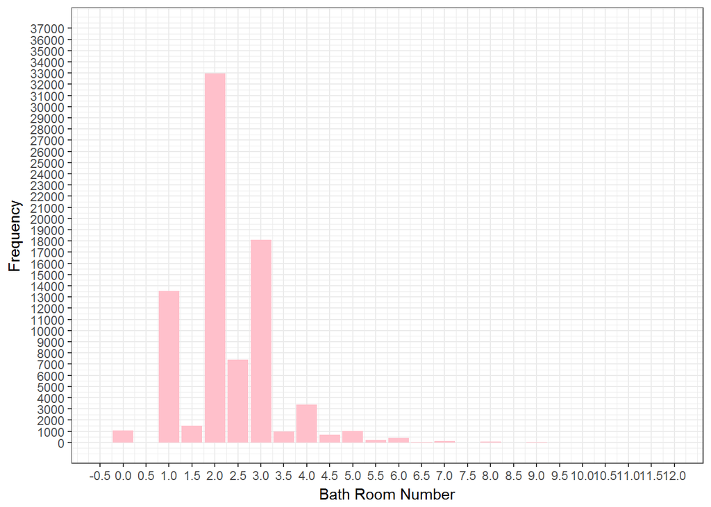

```r
ggplot(bath) + geom_bar(aes(x= bathroomcnt, y=nrow), fill = "pink", stat = "identity") + xlab("Bath Room Number") + ylab("Frequency")+ scale_y_continuous(limits = c(0, 37000), breaks = seq(0, 37000, 1000)) + scale_x_continuous(limits = c(-0.5, 12), breaks = seq(-0.5, 12, 0.5)) + theme_bw()
```

# The most popular bedrooms (3 bedrooms then 2 and 4)

```r
bed <-data.frame(ddply(temp16df, .(bedroomcnt), "nrow"))
bed <- arrange(bed, desc(nrow))
head(bed)
```

```
##   bedroomcnt  nrow
## 1          3 32016
## 2          2 20228
## 3          4 18423
## 4          5  4604
## 5          1  3528
## 6          0  1302
```

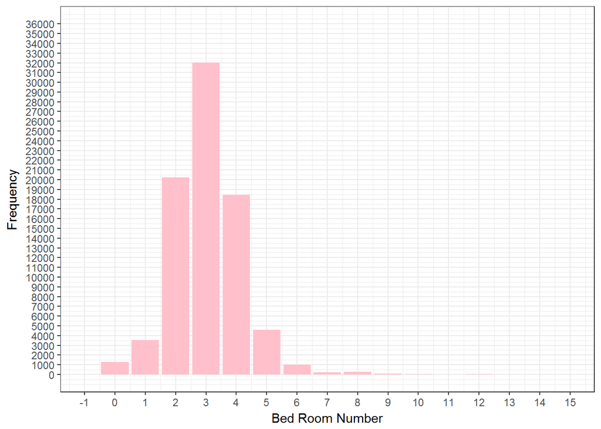

```r
ggplot(bed) + geom_bar(aes(x= bedroomcnt, y=nrow), fill = "pink", stat = "identity") + xlab("Bed Room Number") + ylab("Frequency")+ scale_y_continuous(limits = c(0, 36000), breaks = seq(0, 36000, 1000)) + scale_x_continuous(limits = c(-1, 15), breaks = seq(-1, 15, 1)) + theme_bw()
```

# The most popular property type id (261 - Single Family Residential then 266 - Condominium)

```r
pt <-data.frame(ddply(temp16df, .(propertylandusetypeid), "nrow"))
pt <- arrange(pt, desc(nrow))
head(pt)
```

```
##   propertylandusetypeid  nrow
## 1                   261 54907
## 2                   266 20691
## 3                   246  2122
## 4                   269  2107
## 5                   248   791
## 6                   247   565
```

# The most popular county (6037 - LA, then 6059 - OR, last 6111 - VE)

```r
fips <-data.frame(ddply(temp16df, .(fips), "nrow"))
fips <- arrange(fips, desc(nrow))
head(fips)
```

```
##   fips  nrow
## 1 6037 52853
## 2 6059 22366
## 3 6111  6514
```

# The most popular room (0 room - maybe the value is not supplied, then with 6 rooms and 7 rooms)

```r
room <-data.frame(ddply(temp16df, .(roomcnt), "nrow"))
room <- arrange(room, desc(nrow))
head(room)
```

```
##   roomcnt  nrow
## 1       0 63032
## 2       6  4863
## 3       7  4075
## 4       5  3165
## 5       8  3108
## 6       4  1524
```

# The most popular taxvaluedollarcnt (between 300k and 500k)

```r
tax <-data.frame(ddply(mergeid16, .(taxvaluedollarcnt), "nrow"))
tax <- arrange(tax, desc(nrow), desc(taxvaluedollarcnt))
tax[which.max(tax$taxvaluedollarcnt),]
```

```
##      taxvaluedollarcnt nrow
## 9310          27750000    1
```

```r
tax[which.min(tax$taxvaluedollarcnt),]
```

```
##      taxvaluedollarcnt nrow
## 9309                22    2
```

```r
head(tax)
```

```
##   taxvaluedollarcnt nrow
## 1            500000   53
## 2            420000   53
## 3            400000   52
## 4            350000   52
## 5            390000   51
## 6            440000   47
```

# The most popular squarefeet (around 1200sq.feet=112sq.meter)

```r
feet <-data.frame(ddply(mergeid16, .(calculatedfinishedsquarefeet), "nrow"))
feet <- arrange(feet, desc(nrow))
feet[which.max(feet$calculatedfinishedsquarefeet),]
```

```
##      calculatedfinishedsquarefeet nrow
## 4993                        22741    1
```

```r
feet[which.min(feet$calculatedfinishedsquarefeet),]
```

```
##      calculatedfinishedsquarefeet nrow
## 3895                            2    1
```

```r
head(feet)
```

```
##   calculatedfinishedsquarefeet nrow
## 1                           NA  630
## 2                         1200  169
## 3                         1080  157
## 4                         1440  145
## 5                         1120  142
## 6                         1040  140
```

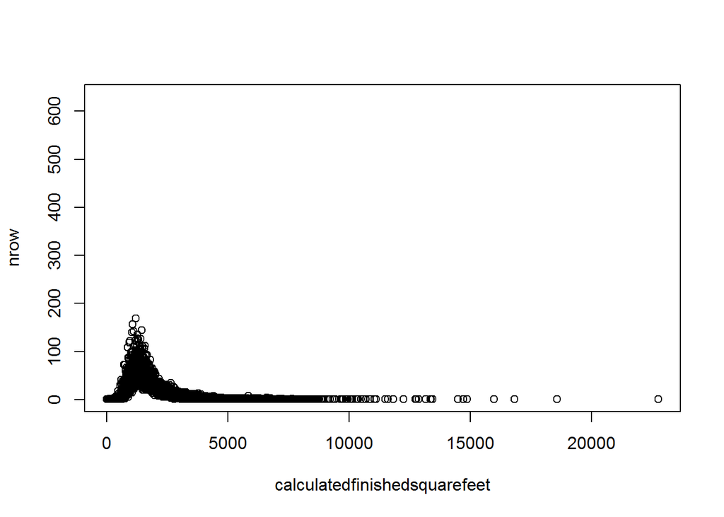

```r
plot(feet)
```